# Fit a constrained tree-volume model

Suppose a volume model should increase with both diameter and height, and multiplying both measurements by a common factor should multiply predicted volume by its cube. These are **modeling assumptions**, not consequences of fitting the data. They lead to a small regression problem with both an equality and inequalities. Euclidean coefficients let us inspect the constraint solver without introducing a geometric representation at the same time.

Start with the regression introduction if the problem-and-solver interface is new to you. The constraints and nonsmooth guide explains the solver contract in more detail.

## Data: diameter, height, and timber volume

R’s [`trees` data](https://stat.ethz.ch/R-manual/R-devel/library/datasets/html/trees.html) contain 31 black cherry trees. The misleadingly named `Girth` column records **diameter in inches**, not circumference. Height is in feet and timber volume in cubic feet. All three variables are positive and complete. No download is needed; see data sources and reproducibility.

```r
trees <- datasets::trees
stopifnot(nrow(trees) == 31, !anyNA(trees), all(as.matrix(trees) > 0))
log_predictors <- log(as.matrix(trees[, c("Girth", "Height")]))
log_volume <- log(trees$Volume)
predictor_center <- colMeans(log_predictors)
response_center <- mean(log_volume)
X <- cbind(intercept = 1, sweep(log_predictors, 2, predictor_center))
y <- log_volume - response_center

registered <- list(
  X = torch_tensor(X, dtype = torch_float64(), device = "cpu"),
  y = torch_tensor(y, dtype = torch_float64(), device = "cpu")
)
```

Centering the log predictors and response improves numerical conditioning and changes only the intercept. We do not standardize the predictors, so the slope constraints keep their original meaning.

## Objective and constraints

Write the model in the original coordinates as

log *V*<sub>*i*</sub> ≈ *a* + *b*<sub>*D*</sub>log *D*<sub>*i*</sub> + *b*<sub>*H*</sub>log *H*<sub>*i*</sub>, *b*<sub>*D*</sub> + *b*<sub>*H*</sub> = 3, *b*<sub>*D*</sub> ≥ 0, *b*<sub>*H*</sub> ≥ 0.

We minimize the mean squared log residual divided by two. In the constructor, equalities have the form *h*(*β*) = 0 and inequalities have the form *g*(*β*) ≤ 0. Our optimization point contains the centered intercept followed by the two slopes. Registered data are passed to every callback, even when a particular callback needs only the coefficients.

```r
problem <- riem.problem.constrained(
  manifold.euclidean(3),
  fn = function(beta, data) {
    (data$X$matmul(beta) - data$y)$square()$mean() / 2
  },
  equality = function(beta, data) (beta[2:3]$sum() - 3)$reshape(1),
  inequality = function(beta, data) -beta[2:3],
  data = registered
)
```

`riem.problem.constrained()` uses automatic differentiation for the objective gradient and constraint adjoints here. The augmented-Lagrangian solver repeatedly solves smooth inner problems and updates its multipliers.

## Solve and inspect termination

```r
initial <- torch_tensor(c(0, 1.5, 1.5), dtype = torch_float64(), device = "cpu")
fit <- riem.optimize(
  problem, initial, method = "augmented_lagrangian",
  control = list(max_iterations = 30, gradient_tolerance = 1e-7,
                 feasibility_tolerance = 1e-7,
                 inner_control = list(max_iterations = 100)),
  device = "cpu"
)
centered_coefficients <- as.numeric(fit$point)
coefficients <- c(
  intercept = centered_coefficients[1] + response_center -
    sum(centered_coefficients[2:3] * predictor_center),
  log_diameter = centered_coefficients[2],
  log_height = centered_coefficients[3]
)
round(coefficients, 6)
```

```
#>    intercept log_diameter   log_height
#>    -6.185685     1.990668     1.009332
```

```r
data.frame(termination = fit$termination, as.data.frame(fit$kkt))
```

```
#>     termination  feasibility stationarity complementarity dual_feasibility
#> 1 converged_kkt 2.241893e-08 5.157096e-08               0                0
```

`converged_kkt` means the feasibility, stationarity, complementarity, and dual feasibility tests passed. An iteration budget or an inner-solver failure is a different outcome and must not be reported as convergence. These residuals usually give local optimality conditions; the independent calculation below also takes advantage of this particular problem’s convexity.

## Visualize the fit

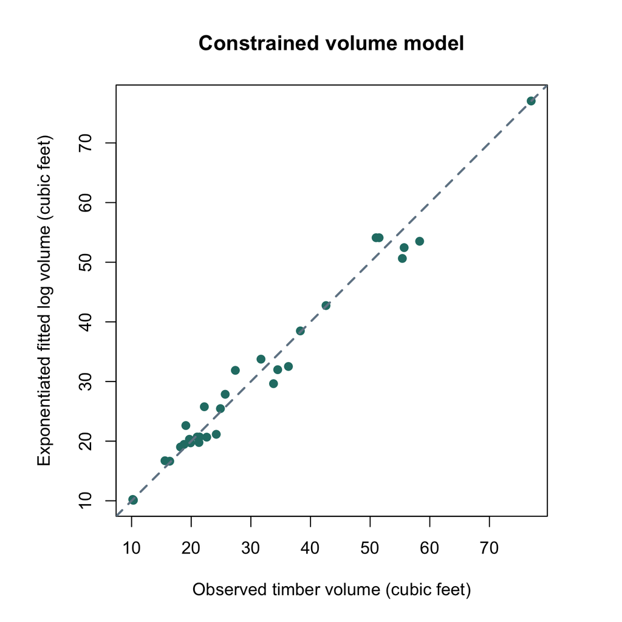

The fit is optimized in log-volume units. Exponentiating a fitted log value does not correct for retransformation bias.

## Independent verification

Eliminate the height slope by setting *b*<sub>*H*</sub> = 3 − *b*<sub>*D*</sub>. Let *z*<sub>*i*</sub> = log *D*<sub>*i*</sub> − log *H*<sub>*i*</sub> and *w*<sub>*i*</sub> = log *V*<sub>*i*</sub> − 3log *H*<sub>*i*</sub>. After profiling out the intercept, this is simple least squares in *b*<sub>*D*</sub>, restricted to $[0, 3]$. The unrestricted slope is a ratio of centered cross products; clipping it to this interval gives the constrained minimum. This reference uses base R rather than another call to the riemtorch solver.

```r
z <- log_predictors[, 1] - log_predictors[, 2]
w <- log_volume - 3 * log_predictors[, 2]
z_centered <- z - mean(z)
w_centered <- w - mean(w)
reference_diameter <- min(3, max(0, sum(z_centered * w_centered) /
                                  sum(z_centered^2)))
reference <- c(intercept = mean(w) - reference_diameter * mean(z),
               log_diameter = reference_diameter,
               log_height = 3 - reference_diameter)
coefficient_error <- max(abs(coefficients - reference))

# Independently evaluate the Lagrangian gradient and all constraint residuals.
beta <- centered_coefficients
lambda <- as.numeric(fit$multipliers$equality)
mu <- as.numeric(fit$multipliers$inequality)
objective_gradient <- drop(crossprod(X, drop(X %*% beta) - y)) / nrow(X)
lagrangian_gradient <- objective_gradient + c(0, lambda, lambda) - c(0, mu)
independent_kkt <- c(
  feasibility = max(abs(sum(beta[2:3]) - 3), pmax(0, -beta[2:3])),
  stationarity = sqrt(sum(lagrangian_gradient^2)),
  complementarity = max(abs(mu * beta[2:3])),
  dual_feasibility = max(0, -mu)
)
rbind(riemtorch = coefficients, independent = reference)
```

```
#>             intercept log_diameter log_height
#> riemtorch   -6.185685     1.990668   1.009332
#> independent -6.185685     1.990667   1.009333
```

```r
data.frame(maximum_coefficient_error = coefficient_error,
           as.list(independent_kkt), check.names = FALSE)
```

```
#>   maximum_coefficient_error  feasibility stationarity complementarity
#> 1              4.764956e-07 2.241893e-08 5.157096e-08               0
#>   dual_feasibility
#> 1                0
```

```r
stopifnot(fit$termination == "converged_kkt",
          coefficient_error < 2e-5,
          max(independent_kkt) < 1e-6,
          max(abs(unlist(fit$kkt) - independent_kkt)) < 1e-8)
```

The fitted slopes are close to the familiar diameter-squared-times-height relationship. That agreement does not establish that the constraints are appropriate for another species or population. Predictions shown here are in-sample and are not a forecast accuracy assessment.

## Choose a device for your own run

All code above uses CPU float64 explicitly so the published result is easy to reproduce. `riem.optimize()` accepts `device = "auto"` to discover a suitable device, `device = "cpu"` to override an available GPU, or an indexed CUDA device on a compatible workstation. Registered tensors travel with the problem.

```r
# Change only the device argument in the solve above:
# device = "auto"    # automatic selection while preserving float64
# device = "cpu"     # explicit CPU override
# device = "cuda:0"  # explicit first CUDA GPU; errors if unavailable
```